# Database for regression: cleaned and descriptive analysis

```r
library(readr)
library(dplyr)
library(kableExtra)
#library(tidyr)
library(corrplot)
library(doParallel)
library(psych)
library(ggplot2)
```

```r
setwd("D:/Memoire/application")
```

# Grades in Portugal

```r
source("nettoyage_donnees.R")
```

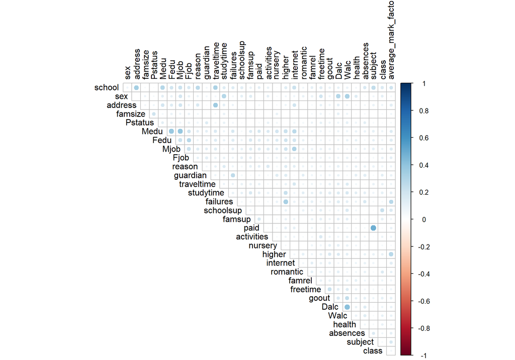

```r
corrplot(
  cramer.matrix(data_cleaned_classification), type="upper", diag=FALSE, tl.col="black"
  )
```

# German cars

This database comes from the following website: https://www.kaggle.com/ander289386/cars-germany

Presentation of the dataset:

- mileage: kilometers traveled by the vehicule.
- make: make of the car.
- model: model of the car.
- fuel: fuel type.
- gear: manual, automatic or semi-automatic.
- offerType: type of offer such as new, used, pre-registered, demonstration and employee’s car.
- price: sale price of the vehicule.
- hp: horse power of the vehicule.
- year: the vehicule registration year.

```r
data_cars <- read.csv("autoscout24-germany-dataset.csv", sep= ",")
```

Features with no problems:

- make
- offerType

```r
data_cars$make <- as.factor(data_cars$make)
levels(data_cars$make)
```

```
##  [1] "9ff"               "Abarth"            "Aixam"
##  [4] "Alfa"              "Alpina"            "Alpine"
##  [7] "Aston"             "Audi"              "Baic"
## [10] "Bentley"           "BMW"               "Brilliance"
## [13] "Cadillac"          "Caravans-Wohnm"    "Chevrolet"
## [16] "Chrysler"          "Citroen"           "Corvette"
## [19] "Cupra"             "Dacia"             "DAF"
## [22] "Daihatsu"          "DFSK"              "Dodge"
## [25] "DS"                "Estrima"           "Ferrari"
## [28] "Fiat"              "FISKER"            "Ford"
## [31] "Honda"             "Hyundai"           "Infiniti"
## [34] "Isuzu"             "Iveco"             "Jaguar"
## [37] "Jeep"              "Kia"               "Lada"
## [40] "Lamborghini"       "Lancia"            "Land"
## [43] "Lexus"             "Ligier"            "Maserati"
## [46] "Maybach"           "Mazda"             "McLaren"
## [49] "Mercedes-Benz"     "Microcar"          "MINI"
## [52] "Mitsubishi"        "Morgan"            "Nissan"
## [55] "Opel"              "Others"            "Peugeot"
## [58] "Piaggio"           "Polestar"          "Porsche"
## [61] "RAM"               "Renault"           "Rolls-Royce"
## [64] "SEAT"              "Skoda"             "smart"
## [67] "SsangYong"         "Subaru"            "Suzuki"
## [70] "Tazzari"           "Tesla"             "Toyota"
## [73] "Trailer-AnhÃ¤nger" "Trucks-Lkw"        "Volkswagen"
## [76] "Volvo"             "Zhidou"
```

```r
data_cars$offerType <- as.factor(data_cars$offerType)
levels(data_cars$offerType)
```

```
## [1] "Demonstration"  "Employee's car" "New"            "Pre-registered"
## [5] "Used"
```

Features that need work:

Gear: we remove the data because there are not much of them and because we do not have the informations necessary about the gear (it exists only automatic, semi-automatic and manual).

```r
data_cars$gear <- as.factor(data_cars$gear)
levels(data_cars$gear)
```

```
## [1] ""               "Automatic"      "Manual"         "Semi-automatic"
```

```r
data_cars[data_cars$gear=="",] <- NA

table(is.na(data_cars$gear))
```

```
##
## FALSE  TRUE
## 46223   182
```

```r
## we remove the first NA
data_cars <- na.omit(data_cars)
data_cars <- droplevels(data_cars)
```

Model: we remove the data because we miss only 126 models and there are no ways of knowing the model of the cars.

```r
data_cars$model <- as.factor(data_cars$model)
levels(data_cars$model)
```

```
##   [1] ""                             "107"
##   [3] "108"                          "114"
##   [5] "116"                          "118"
##   [7] "120"                          "123"
##   [9] "124 Spider"                   "125"
##  [11] "135"                          "140"
##  [13] "1500"                         "2"
##  [15] "2008"                         "206"
##  [17] "207"                          "208"
##  [19] "214"                          "216"
##  [21] "218"                          "220"
##  [23] "225"                          "230"
##  [25] "235"                          "240"
##  [27] "250"                          "3"
##  [29] "3-Wheeler"                    "300"
```

[output cut: 403 more lines]

```r
nrow(data_cars[data_cars$model=="",])
```

```
## [1] 126
```

```r
data_cars[data_cars$model=="",] <- NA

table(is.na(data_cars$model))
```

```
##
## FALSE  TRUE
## 46071   126
```

```r
## we remove the NA
data_cars <- na.omit(data_cars)
data_cars <- droplevels(data_cars)
```

Fuel: I searched every model on the internet. Because there were not much cars that had no fuel type (22 in total) I decided to remove them from the dataframe. I just decided to change the fuel to “Electric” for Tesla Model X. In the end, I removed 20 more data.

```r
data_cars$fuel <- as.factor(data_cars$fuel)
levels(data_cars$fuel)
```

```
##  [1] "-/- (Fuel)"        "CNG"               "Diesel"
##  [4] "Electric"          "Electric/Diesel"   "Electric/Gasoline"
##  [7] "Ethanol"           "Gasoline"          "Hydrogen"
## [10] "LPG"               "Others"
```

```r
data_cars[data_cars$fuel=="-/- (Fuel)",]
```

```
##       mileage       make        model       fuel      gear offerType price  hp
## 287    120500      Honda        Civic -/- (Fuel)    Manual      Used  8990 141
## 304     53000      Skoda        Fabia -/- (Fuel)    Manual      Used  8990 110
## 777      3500 Volkswagen       Passat -/- (Fuel) Automatic      Used 34900 156
## 2987   110000       Ford       Fiesta -/- (Fuel) Automatic      Used  8900 101
## 3662    49200    Hyundai          i30 -/- (Fuel)    Manual      Used  9990 135
## 3908    86000      Tesla      Model X -/- (Fuel) Automatic      Used 69700 562
## 3909    86000      Tesla      Model X -/- (Fuel) Automatic      Used 69700 562
## 4870     1500       Ford       Fiesta -/- (Fuel)    Manual      Used 14990  75
## 7092    18521    Renault          ZOE -/- (Fuel) Automatic      Used  8995  92
## 12132   83000      Skoda      Octavia -/- (Fuel)    Manual      Used 10900 110
## 17713   91229 Volkswagen          up! -/- (Fuel)    Manual      Used  6950  68
## 19984   43126       Ford       Fiesta -/- (Fuel)    Manual      Used 10990 101
## 21477   52779    Hyundai       Tucson -/- (Fuel)    Manual      Used 17490 177
## 23939  120000     Nissan        Micra -/- (Fuel)    Manual      Used  5555  80
```

[output cut: 31 more lines]

```r
data_cars$fuel[data_cars$fuel=="-/- (Fuel)"&data_cars$model=="Model X"] <- "Electric"

data_cars[data_cars$fuel=="-/- (Fuel)",] <- NA

data_cars <- na.omit(data_cars)
data_cars <- droplevels(data_cars)
```

I verified the missing values on the new set:

```r
table(is.na(data_cars))
```

```
##
##  FALSE
## 414459
```

No missing values left.

## Numerical features

Mileage: there is a problem with the Opel Karl, it has done more than 1 million kms since 2019 which is certainly not possible. We will remove this value.

```r
data_cars[data_cars$mileage>600000,]
```

```
##       mileage          make    model     fuel   gear     offerType price  hp
## 16870 1111111          Opel     Karl Gasoline Manual Demonstration 10490  73
## 25439  620000 Mercedes-Benz     Vito   Diesel Manual          Used  6500 163
## 34745  699000 Mercedes-Benz Sprinter   Diesel Manual          Used  3990 163
##       year
## 16870 2019
## 25439 2014
## 34745 2011
```

```r
data_cars <- data_cars[data_cars$mileage!=1111111,]
```

Price: the price is very high for the 3 cars but they are possible prices for supercars like them so I decided to keep them.

```r
data_cars[data_cars$price>600000,]
```

```
##       mileage          make   model     fuel      gear offerType   price  hp
## 11754      90       Maybach Pullman Gasoline Automatic      Used  717078 630
## 11755      90 Mercedes-Benz   S 650 Gasoline Automatic      Used  717078 630
## 21676     431       Ferrari     F12 Gasoline Automatic      Used 1199900 775
##       year
## 11754 2019
## 11755 2019
## 21676 2017
```

Hp: the highest horse power that a car has is 850 so there is nothing weird for the hp feature.

```r
data_cars[data_cars$hp>750,]
```

```
##       mileage          make     model     fuel      gear      offerType   price
## 7384    14090   Lamborghini Aventador Gasoline Automatic Employee's car  439900
## 7385     3600   Lamborghini Aventador Gasoline Automatic           Used  449900
## 18420    6500       Ferrari       812 Gasoline Automatic  Demonstration  439900
## 20999   71099         Tesla   Model S Electric Automatic           Used   54450
## 21676     431       Ferrari       F12 Gasoline Automatic           Used 1199900
## 23327   14022   Lamborghini Aventador Gasoline Automatic           Used  349800
## 24390   11000          Audi        R8 Gasoline Automatic           Used  295000
## 40405   63205         Tesla   Model X Electric Automatic           Used   99999
## 43127    9234 Mercedes-Benz  G 63 AMG Gasoline Automatic           Used  216619
## 43141    9790      Corvette       Z06 Gasoline Automatic  Demonstration  148600
## 45695      50          Ford   Mustang Gasoline Automatic           Used  121000
##        hp year
## 7384  770 2021
## 7385  770 2021
## 18420 799 2021
## 20999 772 2015
## 21676 775 2017
## 23327 751 2015
## 24390 799 2013
## 40405 772 2016
## 43127 850 2019
## 43141 767 2019
## 45695 771 2021
```

Year:

```r
tab_fun(table(as.factor(data_cars$year)), title = "Number of cars per year")
```

Number of cars per year

| Var1 | Freq |
| --- | --- |
| 2011 | 4094 |
| 2012 | 4177 |
| 2013 | 4236 |
| 2014 | 4147 |
| 2015 | 4175 |
| 2016 | 4233 |
| 2017 | 4195 |
| 2018 | 4200 |
| 2019 | 4190 |
| 2020 | 4251 |
| 2021 | 4152 |

## Correlation between features

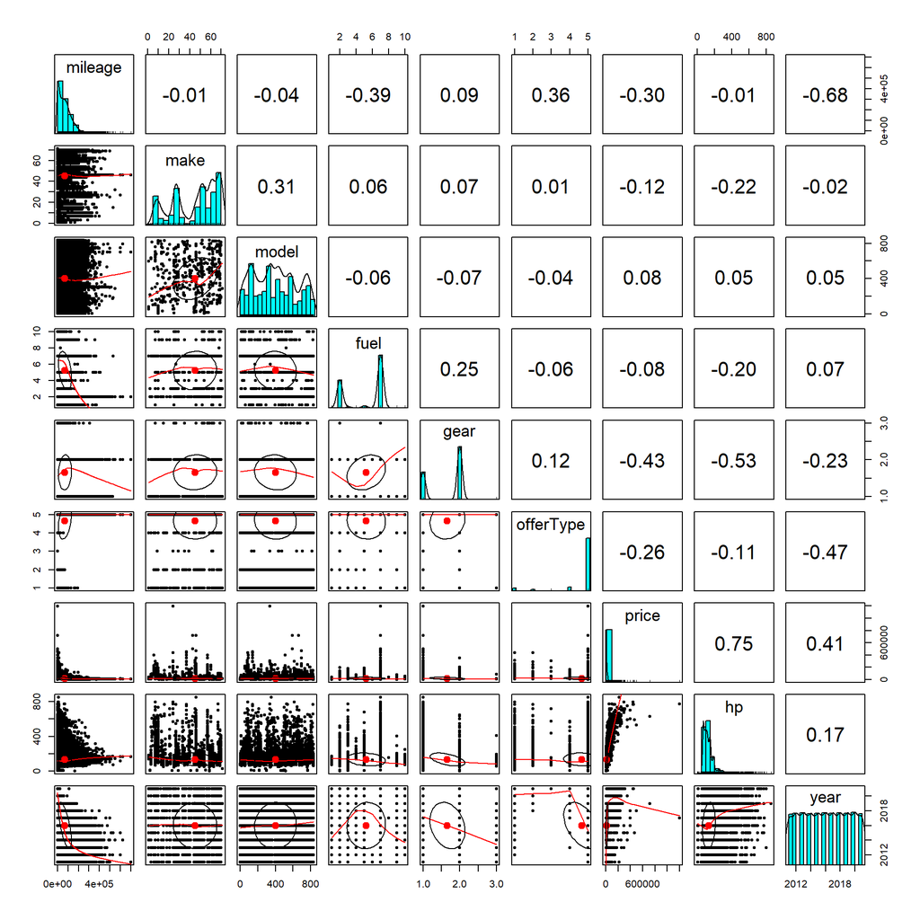

```r
cl <- detectCores() %>% -1 %>% makeCluster
registerDoParallel(cl)

pairs.panels(data_cars)
```

```r
stopCluster(cl)
```

There is a high correlation between price and horsepower (0.75) and between mileage and year (-0.68).

## Descriptive analysis

### Summary of the features

```r
summary(data_cars)
```

```
##     mileage               make           model                      fuel
##  Min.   :     0   Volkswagen: 6904   Golf   : 1489   Gasoline         :28719
##  1st Qu.: 19887   Opel      : 4787   Corsa  : 1485   Diesel           :15178
##  Median : 60000   Ford      : 4406   Fiesta : 1269   Electric/Gasoline: 1146
##  Mean   : 71206   Skoda     : 2872   Astra  : 1190   Electric         :  663
##  3rd Qu.:105000   Renault   : 2789   Focus  :  985   LPG              :  125
##  Max.   :699000   Audi      : 2681   up!    :  942   CNG              :  116
##                   (Other)   :21611   (Other):38690   (Other)          :  103
##              gear                offerType         price               hp
##  Automatic     :15702   Demonstration : 2350   Min.   :   1100   Min.   :  1
##  Manual        :30292   Employee's car: 1117   1st Qu.:   7490   1st Qu.: 86
##  Semi-automatic:   56   New           :   13   Median :  11000   Median :116
##                         Pre-registered: 2768   Mean   :  16566   Mean   :133
##                         Used          :39802   3rd Qu.:  19490   3rd Qu.:150
##                                                Max.   :1199900   Max.   :850
##
##       year
##  Min.   :2011
##  1st Qu.:2013
##  Median :2016
##  Mean   :2016
##  3rd Qu.:2019
##  Max.   :2021
##
```

### Mileage

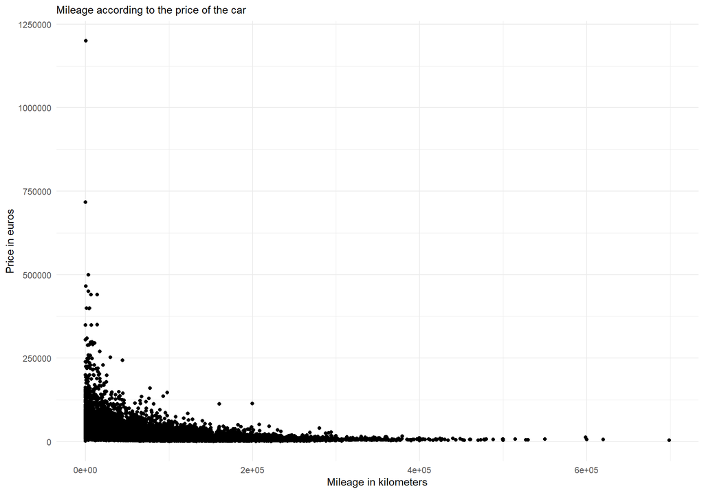

```r
ggplot(aes(x=mileage, y=price), data=data_cars) +
  geom_point() +
  labs(subtitle="Mileage according to the price of the car", x="Mileage in kilometers",
       y="Price in euros") +
  theme_minimal()
```

It looks like that when mileage increases, prices decrease. With this plot, it looks like it is quite difficult to see a relation between the two. It may be better to use the logarithm for these variables.

## Make

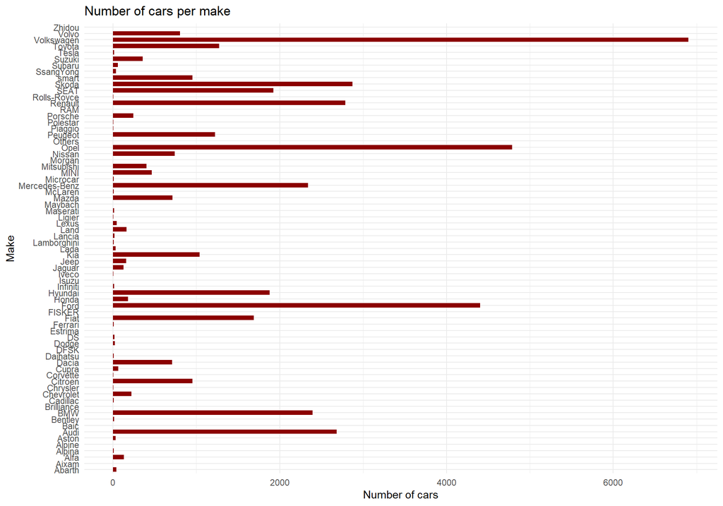

```r
ggplot(data_cars, aes(x=make))+
  geom_bar(stat="count", width=0.7, fill="darkred")+
  theme_minimal() + coord_flip()+
  ggtitle("Number of cars per make")+
  labs(x="Make",y="Number of cars")
```

It looks like there are a lot of Volkswagen, Opel and Ford with each make having more than 4000 cars in the dataset. Moreover, we can count 71 makes in this dataset.

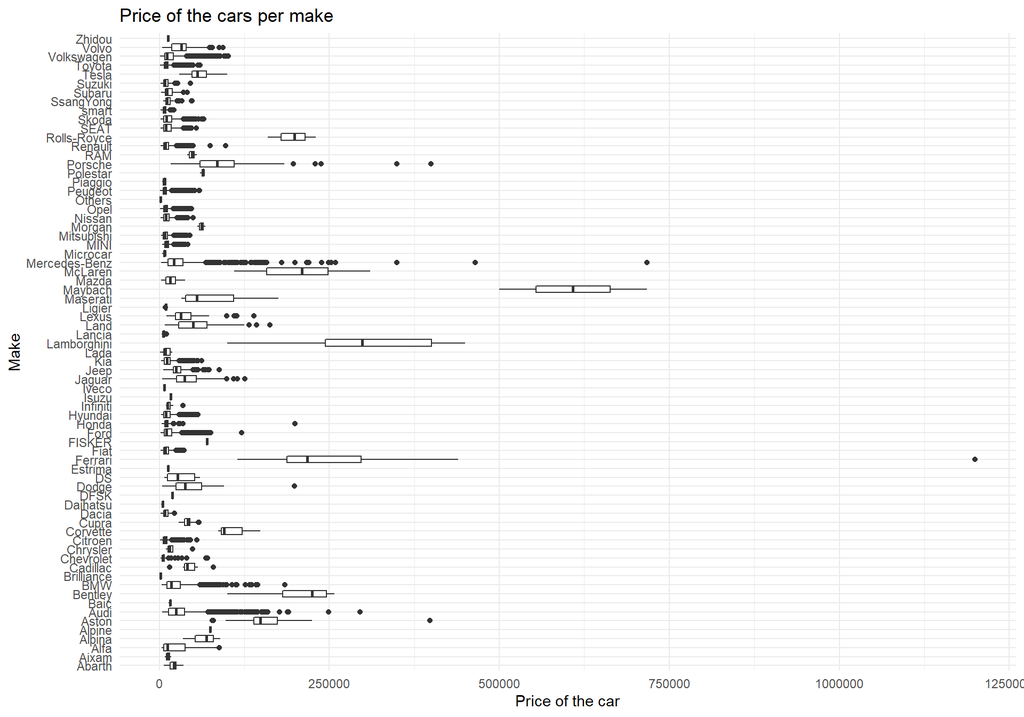

```r
ggplot(data_cars, aes(x=make, y=price))+
  geom_boxplot()+
  theme_minimal() + coord_flip()+
  ggtitle("Price of the cars per make")+
  labs(x="Make",y="Price of the car")
```

## Fuel

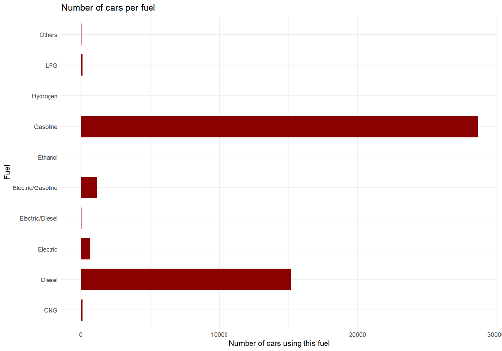

```r
ggplot(data_cars, aes(x=fuel))+
  geom_bar(stat="count", width=0.7, fill="darkred")+
  theme_minimal() + coord_flip()+
  ggtitle("Number of cars per fuel")+
  labs(x="Fuel",y="Number of cars using this fuel")
```

For fuel, most of the cars use gasoline or diesel. We can also see that a few of them are hybrid, here they use electric and gasoline, or electric. Finally, we can see that very few cars are using ethanol and hydrogen (3 in total).

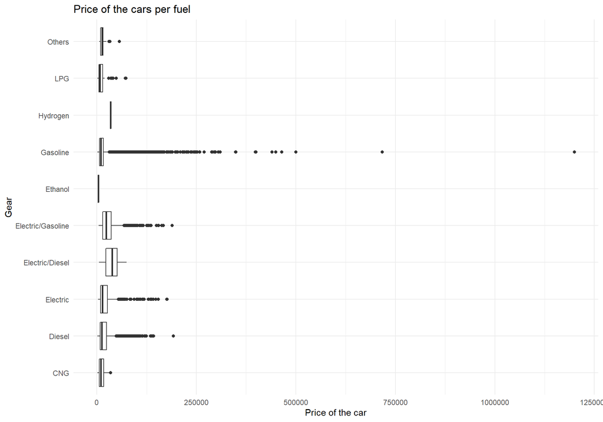

```r
ggplot(data_cars, aes(x=fuel, y=price))+
  geom_boxplot()+
  theme_minimal() + coord_flip()+
  ggtitle("Price of the cars per fuel")+
  labs(x="Gear",y="Price of the car")
```

It appears that there are no relationships between the price and the fuel the cars are using.

## Gear

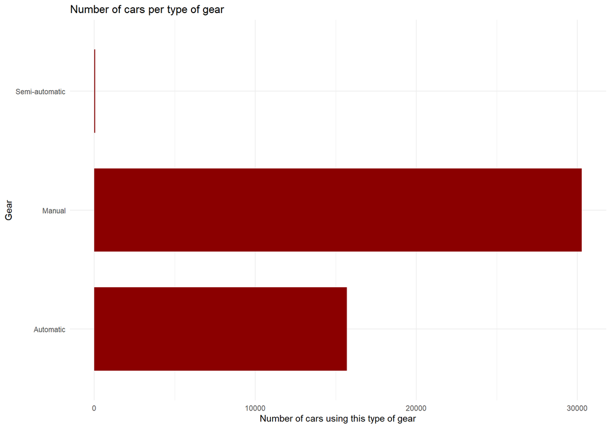

```r
ggplot(data_cars, aes(x=gear))+
  geom_bar(stat="count", width=0.7, fill="darkred")+
  theme_minimal() + coord_flip()+
  ggtitle("Number of cars per type of gear")+
  labs(x="Gear",y="Number of cars using this type of gear")
```

Most of the cars are manual or automatic. A few of them are semi-automatic.

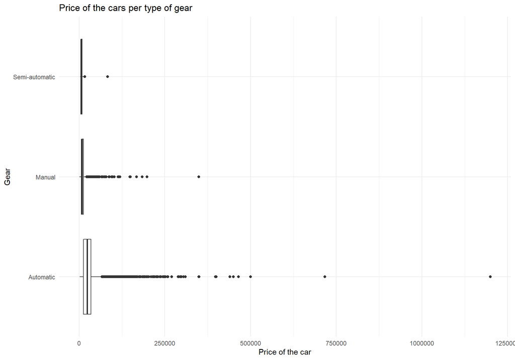

```r
ggplot(data_cars, aes(x=gear, y=price))+
  geom_boxplot()+
  theme_minimal() + coord_flip()+
  ggtitle("Price of the cars per type of gear")+
  labs(x="Gear",y="Price of the car")
```

It looks like that automatic gear increase the price of the car.

## Type of offer

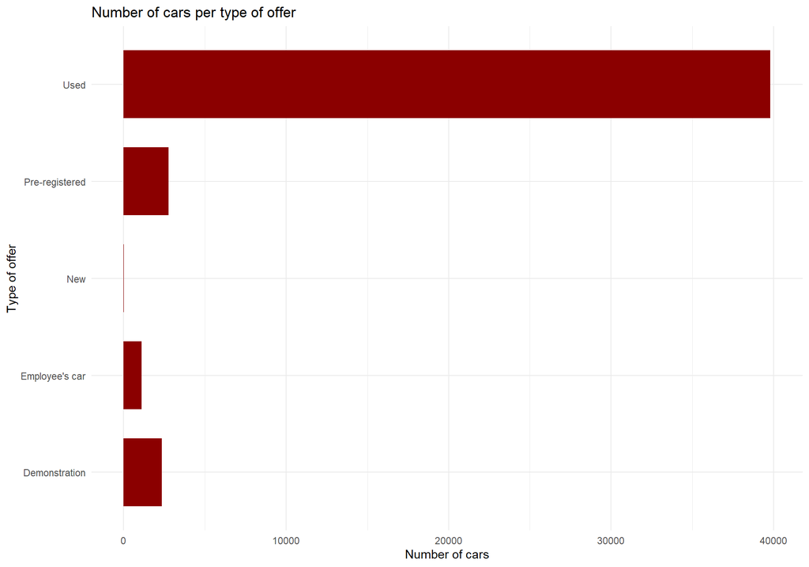

```r
ggplot(data_cars, aes(x=offerType))+
  geom_bar(stat="count", width=0.7, fill="darkred")+
  theme_minimal() + coord_flip()+
  ggtitle("Number of cars per type of offer")+
  labs(x="Type of offer",y="Number of cars")
```

Most of the cars are used cars. There are only a few of them that are new.

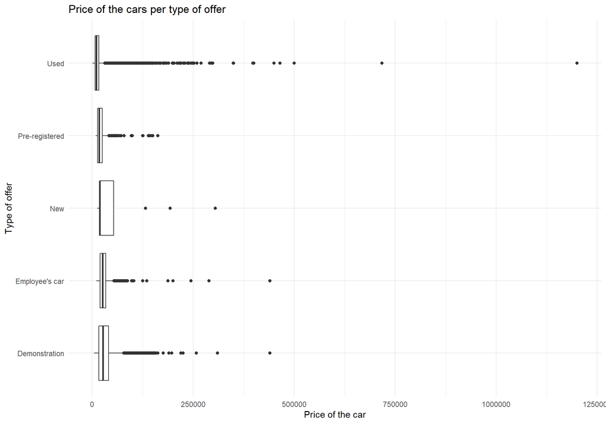

```r
ggplot(data_cars, aes(x=offerType, y=price))+
  geom_boxplot()+
  theme_minimal() + coord_flip()+
  ggtitle("Price of the cars per type of offer")+
  labs(x="Type of offer",y="Price of the car")
```

It appears that there are no relationships between the price of the car and its type of offer.

## Horse power

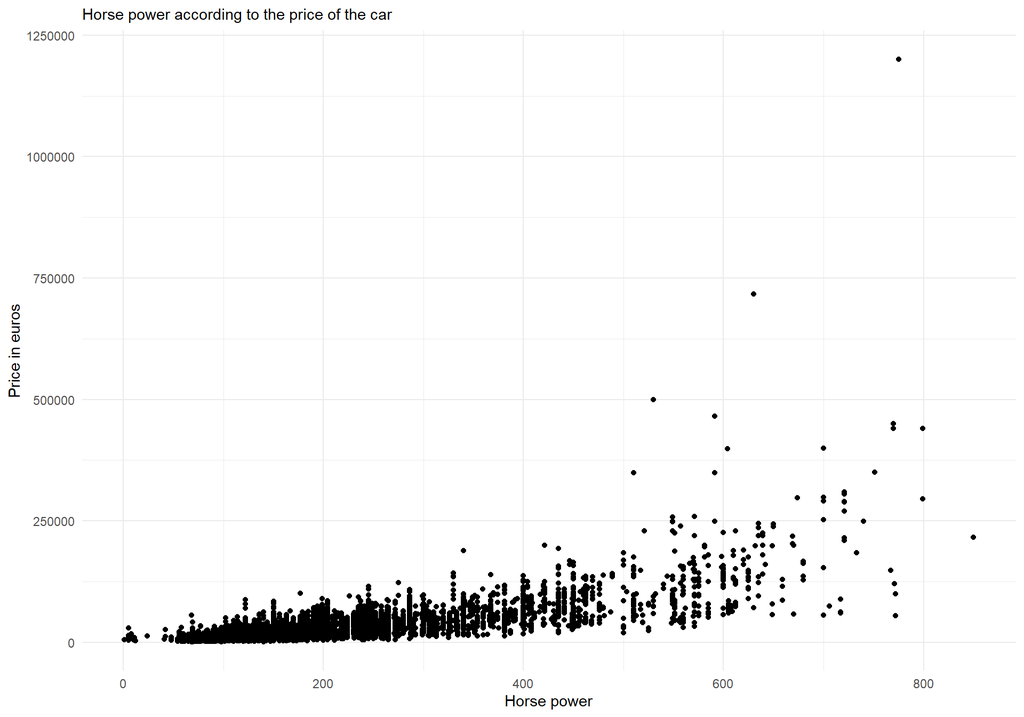

```r
ggplot(aes(x=hp, y=price), data=data_cars) +
  geom_point() +
  labs(subtitle="Horse power according to the price of the car", x="Horse power",
       y="Price in euros") +
  theme_minimal()
```

It looks like that the higher the horse power, the higher the price.

## Year

```r
data_cars$year <- as.factor(data_cars$year)
```

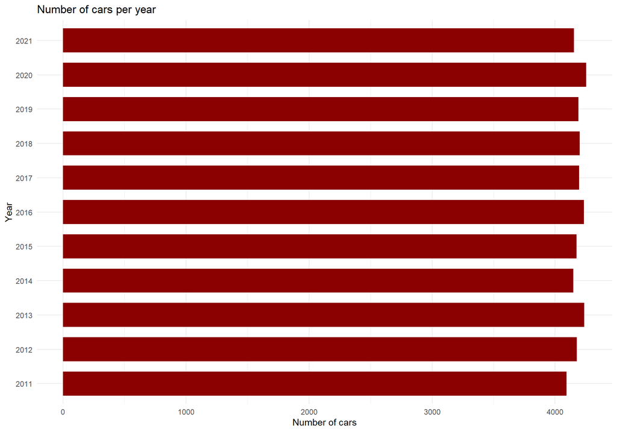

```r
ggplot(data_cars, aes(x=year))+
  geom_bar(stat="count", width=0.7, fill="darkred")+
  theme_minimal() + coord_flip()+
  ggtitle("Number of cars per year")+
  labs(x="Year",y="Number of cars")
```

It looks like we have almost the same number of cars per year.

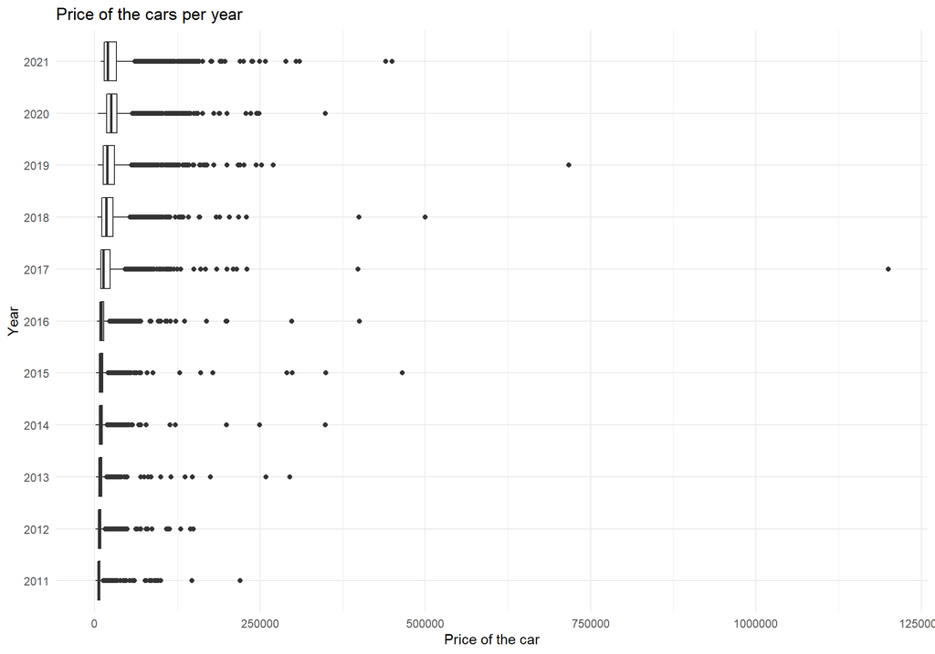

```r
ggplot(data_cars, aes(x=year, y=price))+
  geom_boxplot()+
  theme_minimal() + coord_flip()+
  ggtitle("Price of the cars per year")+
  labs(x="Year",y="Price of the car")
```

It appears that there is a relationship between the years and the price of the cars. One of the reasons could be inflation. Indeed, the higher the year, the higher the price, so this could mean that because prices have risen since 2011, cars are now more expensive.

# Export of the database

```r
require("writexl")
write_xlsx(data_cleaned_classification, "D:/Memoire/application/data_classification.xlsx")
write_xlsx(data_cars, "D:/Memoire/application/data_regression.xlsx")
```